# Red Wine Exploration by Mohamed Aly

# Multivariate Analysis

### Talk about some of the relationships you observed in this part of the investigation. Were there features that strengthened each other in terms of looking at your feature(s) of interest?

As a result of trying different combinations of features, it seems that it depends on them all together, there is no unique or specefic feature that influences the wine quality on it’s own, but different combinations of features with a considerable effect of alcohol than other features.

### Were there any interesting or surprising interactions between features?

A lot of features have no great effect on quality of wine, but a combination of different features together make the effect.

# Final Plots and Summary

### Plot One

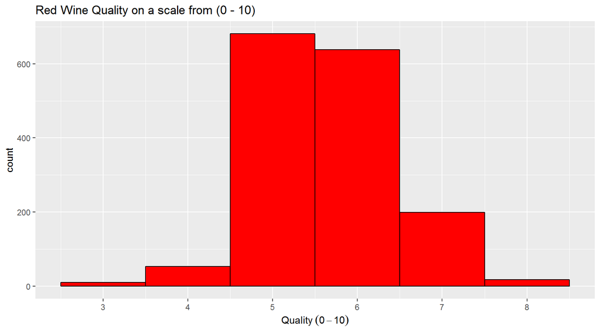

### Description One

It’s obvious that finding a high quality red wine is rare, and also for low quality wine. we can find red wine quality to be mostly 5 or 6. this distribution shows us the resultant red wine quality of our dataset.

### Plot Two

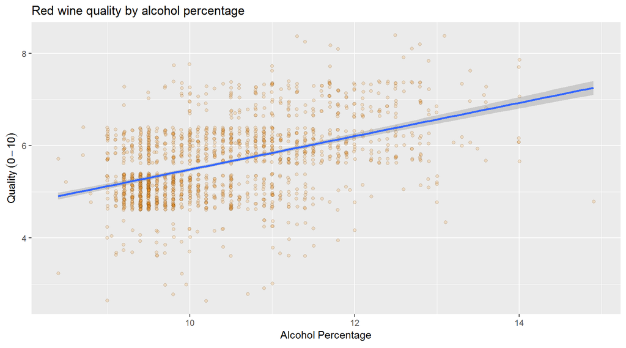

### Description Two

The most feature the affects the red wine quality from our dataset is the alcohol percentage, which seems to be positive correlated with the wine quality.

### Plot Three

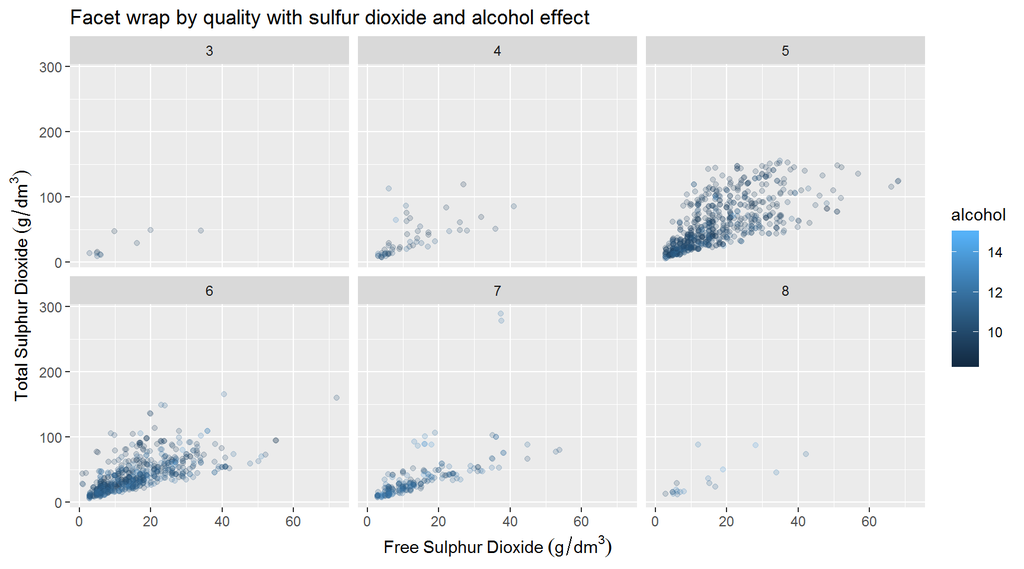

# Reflection

It was a really interesting project, that helps me summarize all what i had learnt in this module. At the begining of the project i was quitely confused, but i started working and here i am, also i struggled with the data set as it’s only quantitative and no categorical features which i think would break the routine of the data. I really enjoyed learning “R”, a strong data analysis tool which will help me in the future a lot. For future work, you can add a different data structure features like categorical and quantitative data set features not only quantitative like this data set, in order to be more diverse, also you can add student to student review in order to learn from others mistakes.